# experiment1_4_HW_2

Experiment 1: DNN with 2 layers (no regularization)

Experiment 2: DNN with 3 layers (no regularization)

Experiment 3: CNN with 2 convolution/max pooling layers (no regularization)

Experiment 4: CNN with 3 convolution/max pooling layers (no regularization)

Result1: Create a table with the accuracy and loss for train/test/validation & process time for ALL the models.

Result2: Take Experiment 3 – Extract the outputs from 2 filters from the 2 max pooling layers and visualize them in a grid as images. See whether the ‘lighted’ up regions correspond to some features in the original images.

[reference](https://home.mit.bme.hu/~hadhazi/Oktatas/NN18/dem3/html_demo/CIFAR-10Demo.html)

```python
import numpy as np
import pandas as pd
from packaging import version

from sklearn.metrics import confusion_matrix, classification_report
from sklearn.metrics import accuracy_score
from sklearn.metrics import mean_squared_error as MSE
from sklearn.model_selection import train_test_split

import matplotlib.pyplot as plt
import seaborn as sns

import tensorflow as tf
import keras
from tensorflow.keras import models, layers
from tensorflow.keras.models import Sequential
from tensorflow.keras.layers import Conv2D, MaxPool2D, BatchNormalization, Dropout, Flatten, Dense
from tensorflow.keras.callbacks import ModelCheckpoint, EarlyStopping
from tensorflow.keras.preprocessing import image
from tensorflow.keras.utils import to_categorical

import time
```

```python
%matplotlib inline
np.set_printoptions(precision=3, suppress=True)
```

```python
#from google.colab import drive
#drive.mount('/content/gdrive')
```

**Functions**

```python
import sys
assert sys.version_info >= (3, 7)
# Is this notebook running on Colab or Kaggle?
IS_COLAB = "google.colab" in sys.modules
IS_KAGGLE = "kaggle_secrets" in sys.modules

if not tf.config.list_physical_devices('GPU'):
    print("No GPU was detected. Neural nets can be very slow without a GPU.")
    if IS_COLAB:
        print("Go to Runtime > Change runtime and select a GPU hardware "
              "accelerator.")
    if IS_KAGGLE:
        print("Go to Settings > Accelerator and select GPU.")
```

```python
def get_three_classes(x, y):
    def indices_of(class_id):
        indices, _ = np.where(y == float(class_id))
        return indices

    indices = np.concatenate([indices_of(0), indices_of(1), indices_of(2)], axis=0)

    x = x[indices]
    y = y[indices]

    count = x.shape[0]
    indices = np.random.choice(range(count), count, replace=False)

    x = x[indices]
    y = y[indices]

    y = tf.keras.utils.to_categorical(y)

    return x, y
```

```python
def show_random_examples(x, y, p):
    indices = np.random.choice(range(x.shape[0]), 10, replace=False)

    x = x[indices]
    y = y[indices]
    p = p[indices]

    plt.figure(figsize=(10, 5))
    for i in range(10):
        plt.subplot(2, 5, i + 1)
        plt.imshow(x[i])
        plt.xticks([])
        plt.yticks([])
        col = 'green' if np.argmax(y[i]) == np.argmax(p[i]) else 'red'
        plt.xlabel(class_names_preview[np.argmax(p[i])], color=col)
    plt.show()
```

```python
def plot_history(history):
  losses = history.history['loss']
  accs = history.history['accuracy']
  val_losses = history.history['val_loss']
  val_accs = history.history['val_accuracy']
  epochs = len(losses)

  plt.figure(figsize=(16, 4))
  for i, metrics in enumerate(zip([losses, accs], [val_losses, val_accs], ['Loss', 'Accuracy'])):
    plt.subplot(1, 2, i + 1)
    plt.plot(range(epochs), metrics[0], label='Training {}'.format(metrics[2]))
    plt.plot(range(epochs), metrics[1], label='Validation {}'.format(metrics[2]))
    plt.legend()
  plt.show()
```

```python
def print_validation_report(y_test, predictions):
    print("Classification Report")
    print(classification_report(y_test, predictions))
    print('Accuracy Score: {}'.format(accuracy_score(y_test, predictions)))
    print('Root Mean Square Error: {}'.format(np.sqrt(MSE(y_test, predictions))))
```

```python
def plot_confusion_matrix(y_true, y_pred):
    mtx = confusion_matrix(y_true, y_pred)
    fig, ax = plt.subplots(figsize=(8,8))
    sns.heatmap(mtx, annot=True, fmt='d', linewidths=.75,  cbar=False, ax=ax,cmap='Blues',linecolor='white')
    #  square=True,
    plt.ylabel('true label')
    plt.xlabel('predicted label')
```

**Data**

```python
(x_train, y_train), (x_test, y_test) = keras.datasets.cifar10.load_data()
```

```
Downloading data from https://www.cs.toronto.edu/~kriz/cifar-10-python.tar.gz
```

```python
print('train_images:\t{}'.format(x_train.shape))
print('train_labels:\t{}'.format(y_train.shape))
print('test_images:\t\t{}'.format(x_test.shape))
print('test_labels:\t\t{}'.format(y_test.shape))
```

```
train_images:	(50000, 32, 32, 3)
train_labels:	(50000, 1)
test_images:		(10000, 32, 32, 3)
test_labels:		(10000, 1)
```

```python
class_names = ['airplane'
,'automobile'
,'bird'
,'cat'
,'deer'
,'dog'
,'frog'
,'horse'
,'ship'
,'truck']
```

```python
x_train_split, x_valid_split, y_train_split, y_valid_split = train_test_split(x_train
                                                                              ,y_train
                                                                              ,test_size=.1
                                                                              ,random_state=42
                                                                              ,shuffle=True)
```

```python
print(x_train_split.shape, x_valid_split.shape, x_test.shape)
```

```
(45000, 32, 32, 3) (5000, 32, 32, 3) (10000, 32, 32, 3)
```

```python
x_train_norm = x_train_split/255
x_valid_norm = x_valid_split/255
x_test_norm = x_test/255
```

```python
print(x_train_split.shape, x_valid_split.shape, x_test.shape)
```

```
(45000, 32, 32, 3) (5000, 32, 32, 3) (10000, 32, 32, 3)
```

```python
x_train_norm.shape
```

```
(45000, 32, 32, 3)
```

```python
x_train_norm.shape[1:]
```

```
(32, 32, 3)
```

**Experiment 1: DNN with 2 layers (no regularization)**

```python
from keras.models import Sequential
from keras.layers import Dense, Activation
from keras.optimizers import Adam

model1 = Sequential([
    Flatten(input_shape = x_train_norm.shape[1:]),
    Dense(units = 256, activation='relu'),
    Dense(units = 10, activation='softmax', name = "output_layer")
])

# Compile the model
model1.compile(optimizer='adam',
              loss=tf.keras.losses.SparseCategoricalCrossentropy(from_logits=False),
              metrics=['accuracy'])
# Print the model summary
model1.summary()
```

```
Model: "sequential"
_________________________________________________________________
 Layer (type)                Output Shape              Param #
=================================================================
 flatten (Flatten)           (None, 3072)              0

 dense (Dense)               (None, 256)               786688

 output_layer (Dense)        (None, 10)                2570

=================================================================
Total params: 789258 (3.01 MB)
Trainable params: 789258 (3.01 MB)
Non-trainable params: 0 (0.00 Byte)
_________________________________________________________________
```

```python
t0 = time.time()
history1 = model1.fit(x_train_norm,
                      y_train_split,
                      epochs=20,
                      batch_size=64,
                      validation_data=(x_valid_norm, y_valid_split)
                   )
training_time1 = time.time()-t0
```

```python
pred = model1.evaluate(x_test_norm, y_test)
list1= [history1.history['accuracy'][-1],history1.history['loss'][-1],
        history1.history['val_accuracy'][-1],history1.history['val_loss'][-1],
        pred[0],pred[1],training_time1]
print(f"Test acc: {pred[1]:.3f}")
```

```
Test acc: 0.474
```

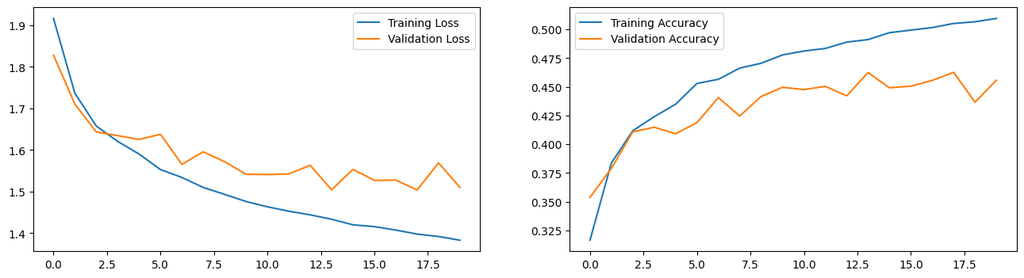

```python
plot_history(history1)
```

**Experiment 2: DNN with 3 layers (no regularization)**

```python
model2 = Sequential([
    Flatten(input_shape=x_train_norm.shape[1:]),
    Dense(256, activation='relu', input_shape=x_train_norm.shape[1:]),
    Dense(128, activation='relu'),
    Dense(10, activation='softmax')
])

# Compile the model
model2.compile(optimizer='adam',
              loss=tf.keras.losses.SparseCategoricalCrossentropy(from_logits=False),
              metrics=['accuracy'])
# Print the model summary
model2.summary()

t0 = time.time()
history2 = model2.fit(x_train_norm
                    ,y_train_split
                    ,epochs=20
                    ,batch_size=64
                    ,validation_data=(x_valid_norm, y_valid_split)
                   )
training_time2 = time.time()-t0
```

```
Model: "sequential_1"
_________________________________________________________________
 Layer (type)                Output Shape              Param #
=================================================================
 flatten_1 (Flatten)         (None, 3072)              0

 dense_1 (Dense)             (None, 256)               786688

 dense_2 (Dense)             (None, 128)               32896

 dense_3 (Dense)             (None, 10)                1290

=================================================================
Total params: 820874 (3.13 MB)
Trainable params: 820874 (3.13 MB)
Non-trainable params: 0 (0.00 Byte)
_________________________________________________________________
```

```python
pred = model2.evaluate(x_test_norm, y_test)
list2= [history2.history['accuracy'][-1],history2.history['loss'][-1],
        history2.history['val_accuracy'][-1],history2.history['val_loss'][-1],
        pred[0],pred[1],training_time2]
print(f"Test acc: {pred[1]:.3f}")
```

```
Test acc: 0.502
```

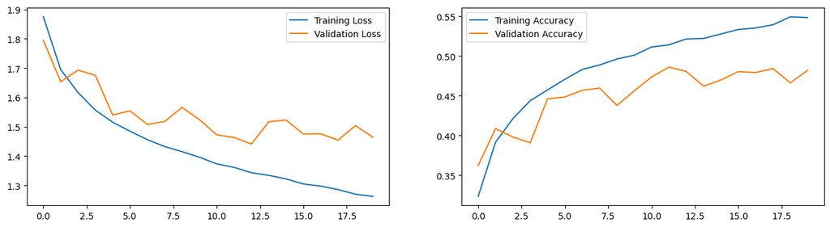

```python
plot_history(history2)
```

**Experiment 3: CNN with 2 convolution/max pooling layers (no regularization)**

```python
from keras.layers import Conv2D, MaxPooling2D, Flatten, Dense

# Define the model architecture
model3 = Sequential([
    # First convolutional layer
    Conv2D(128, (3, 3), activation='relu', input_shape=x_train_norm.shape[1:]),
    MaxPooling2D((2, 2)),

    # Second convolutional layer
    Conv2D(256, (3, 3), activation='relu'),
    MaxPooling2D((2, 2)),

    # Flatten layer to convert 2D feature maps to a 1D feature vector
    Flatten(),

    # Fully connected layers
    Dense(128, activation='relu'),
    Dense(10, activation='softmax')
])

# Compile the model
model3.compile(optimizer='adam',
              loss=tf.keras.losses.SparseCategoricalCrossentropy(from_logits=False),
              metrics=['accuracy'])

# Print the model summary
model3.summary()
t0 = time.time()

history3 = model3.fit(x_train_norm
                    ,y_train_split
                    ,epochs=20
                    ,batch_size=64
                    ,validation_data=(x_valid_norm, y_valid_split)
                   )
training_time3 = time.time()-t0
```

```
Model: "sequential_2"
_________________________________________________________________
 Layer (type)                Output Shape              Param #
=================================================================
 conv2d (Conv2D)             (None, 30, 30, 128)       3584

 max_pooling2d (MaxPooling2  (None, 15, 15, 128)       0
 D)

 conv2d_1 (Conv2D)           (None, 13, 13, 256)       295168

 max_pooling2d_1 (MaxPoolin  (None, 6, 6, 256)         0
 g2D)

 flatten_2 (Flatten)         (None, 9216)              0

 dense_4 (Dense)             (None, 128)               1179776

 dense_5 (Dense)             (None, 10)                1290

=================================================================
Total params: 1479818 (5.65 MB)
Trainable params: 1479818 (5.65 MB)
Non-trainable params: 0 (0.00 Byte)
_________________________________________________________________
```

```python
pred = model3.evaluate(x_test_norm, y_test)
list3= [history3.history['accuracy'][-1],history3.history['loss'][-1],
        history3.history['val_accuracy'][-1],history3.history['val_loss'][-1],
        pred[0],pred[1],training_time3]
print(f"Test acc: {pred[1]:.3f}")
```

```
Test acc: 0.696
```

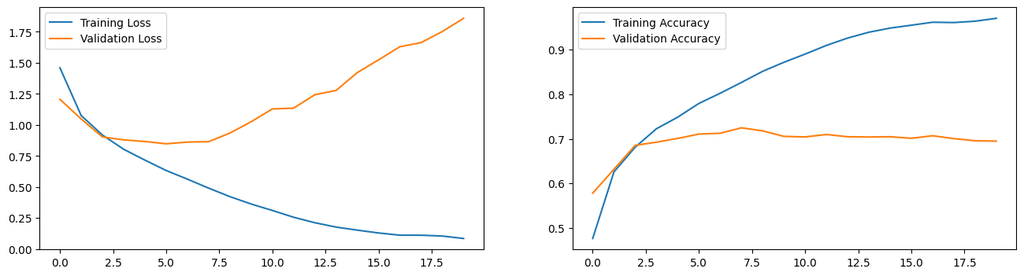

```python
plot_history(history3)
```

**Experiment 4: CNN with 3 convolution/max pooling layers (no regularization)**

```python
model4 = Sequential([
    # First convolutional layer
    Conv2D(128, (3, 3), activation='relu', input_shape=x_train_norm.shape[1:]),
    MaxPooling2D((2, 2)),

    # Second convolutional layer
    Conv2D(256, (3, 3), activation='relu'),
    MaxPooling2D((2, 2)),

    Conv2D(512, (3, 3), activation='relu'),
    MaxPooling2D((2, 2)),

    # Flatten layer to convert 2D feature maps to a 1D feature vector
    Flatten(),

    # Fully connected layers
    Dense(128, activation='relu'),
    Dense(10, activation='softmax')
])

# Compile the model
model4.compile(optimizer='adam',
              loss=tf.keras.losses.SparseCategoricalCrossentropy(from_logits=False),
              metrics=['accuracy'])

# Print the model summary
model4.summary()
t0 = time.time()
history4 = model4.fit(x_train_norm
                    ,y_train_split
                    ,epochs=20
                    ,batch_size=64
                    ,validation_data=(x_valid_norm, y_valid_split)
                   )
training_time4 = time.time()-t0
```

```
Model: "sequential_3"
_________________________________________________________________
 Layer (type)                Output Shape              Param #
=================================================================
 conv2d_2 (Conv2D)           (None, 30, 30, 128)       3584

 max_pooling2d_2 (MaxPoolin  (None, 15, 15, 128)       0
 g2D)

 conv2d_3 (Conv2D)           (None, 13, 13, 256)       295168

 max_pooling2d_3 (MaxPoolin  (None, 6, 6, 256)         0
 g2D)

 conv2d_4 (Conv2D)           (None, 4, 4, 512)         1180160

 max_pooling2d_4 (MaxPoolin  (None, 2, 2, 512)         0
 g2D)

 flatten_3 (Flatten)         (None, 2048)              0

 dense_6 (Dense)             (None, 128)               262272

 dense_7 (Dense)             (None, 10)                1290

=================================================================
Total params: 1742474 (6.65 MB)
Trainable params: 1742474 (6.65 MB)
Non-trainable params: 0 (0.00 Byte)
_________________________________________________________________
```

```python
pred = model4.evaluate(x_test_norm, y_test)
list4= [history4.history['accuracy'][-1],history4.history['loss'][-1],
        history4.history['val_accuracy'][-1],history4.history['val_loss'][-1],
        pred[0],pred[1],training_time4]
print(f"Test acc: {pred[1]:.3f}")
```

```
Test acc: 0.711
```

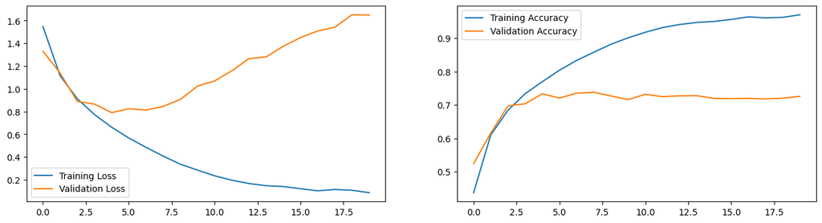

```python
plot_history(history4)
```

**result table:**

```python
results = [list1, list2, list3,list4]
columns = ['training_accuracy','training_loss','val_accuracy','val_loss','testing_loss','testing_accuracy','training_time']
row_names = ['experiment1','experiment2','experiment3','experiment4']

# Create the DataFrame
results_df = pd.DataFrame(results, columns=columns,index = row_names)
results_df
```

|  | training_accuracy | training_loss | val_accuracy | val_loss | testing_loss | testing_accuracy | training_time |
| --- | --- | --- | --- | --- | --- | --- | --- |
| experiment1 | 0.509533 | 1.382931 | 0.4558 | 1.510068 | 1.474805 | 0.4742 | 86.470109 |
| experiment2 | 0.548422 | 1.262606 | 0.4820 | 1.464414 | 1.439394 | 0.5019 | 84.822795 |
| experiment3 | 0.970244 | 0.085064 | 0.6948 | 1.858269 | 1.904641 | 0.6962 | 129.007042 |
| experiment4 | 0.969933 | 0.086562 | 0.7256 | 1.649037 | 1.722972 | 0.7107 | 161.944515 |

```python
results_df.to_excel("results1.xlsx")
```

Result 2: Extract the outputs from 2 filters from the 2 max pooling layers and visualize them in a grid as images. See whether the ‘lighted’ up regions correspond to some features in the original images.

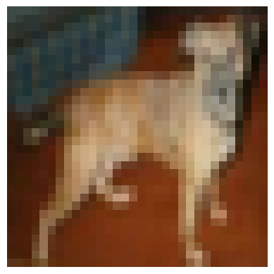

```python
(_,_), (test_images, test_labels) = tf.keras.datasets.cifar10.load_data()

img = test_images[2003]
img_tensor = image.img_to_array(img)
img_tensor = np.expand_dims(img_tensor, axis=0)

class_names = ['airplane'
,'automobile'
,'bird'
,'cat'
,'deer'
,'dog'
,'frog'
,'horse'
,'ship'
,'truck']

plt.imshow(img, cmap='viridis')
plt.axis('off')
plt.show()
```

```python
# Extracts the outputs of the top 8 layers:
layer_outputs = [layer.output for layer in model3.layers[:4]]
# Creates a model that will return these outputs, given the model input:
activation_model = models.Model(inputs=model3.input, outputs=layer_outputs)
```

```python
layer_names = []
for layer in model3.layers:
    layer_names.append(layer.name)

layer_names
```

```
['conv2d',
 'max_pooling2d',
 'conv2d_1',
 'max_pooling2d_1',
 'flatten_2',
 'dense_4',
 'dense_5']
```

```python
activations = activation_model.predict(img_tensor)
len(activations)
```

```
4
```

[figure not shown]

[figure not shown]

```python
# These are the names of the layers, so can have them as part of our plot
layer_names = ['max_pooling2d','max_pooling2d_1']

images_per_row = 16

# Now let's display our feature maps
for layer_name, layer_activation in zip(layer_names, activations):
    # This is the number of features in the feature map
    n_features = layer_activation.shape[-1]

    # The feature map has shape (1, size, size, n_features)
    size = layer_activation.shape[1]

    # We will tile the activation channels in this matrix
    n_cols = n_features // images_per_row
    display_grid = np.zeros((size * n_cols, images_per_row * size))

    # We'll tile each filter into this big horizontal grid
    for col in range(n_cols):
        for row in range(images_per_row):
            channel_image = layer_activation[0,
                                             :, :,
                                             col * images_per_row + row]
            # Post-process the feature to make it visually palatable
            channel_image -= channel_image.mean()
            channel_image /= channel_image.std()
            channel_image *= 64
            channel_image += 128
            channel_image = np.clip(channel_image, 0, 255).astype('uint8')
            display_grid[col * size : (col + 1) * size,
                         row * size : (row + 1) * size] = channel_image

    # Display the grid
    scale = 1. / size
    plt.figure(figsize=(scale * display_grid.shape[1],
                        scale * display_grid.shape[0]))
    plt.title(layer_name)
    plt.grid(False)
    plt.imshow(display_grid, aspect='auto', cmap='viridis')

plt.show();
```